# Analyse descriptive des données opportunistes du GMB

Dans VisioNature, on a deux points avec une très forte densité sont probablement dues à nos deux principaux contributeurs (voir la partie 4), nous décidons de les supprimer pour vérifier.

```r
VN_sf_modif <- VN_sf%>%
  filter(!obsrvtr %in% c("BELLIER DANIEL", "CHAPUIS MARTINE"))

grid_sf <- st_sf(geometry = st_make_grid(carte_bretagne,
                                         cellsize = c(0.12, 0.09))
)
grid_sf$density <- lengths(st_intersects(grid_sf, VN_sf_modif))
grid_sf <- st_intersection(grid_sf, carte_bretagne)
```

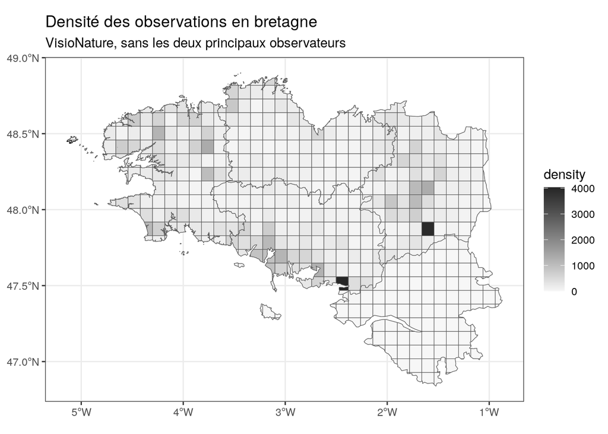

```r
ggplot() +
  geom_sf(data = carte_bretagne) +
  labs(title = "Densité des observations en bretagne",
       subtitle = "VisioNature, sans les deux principaux observateurs") +
  geom_sf(data = grid_sf, aes(fill = density)) +
  scale_fill_gradient(low="grey97", high="gray15") +
  theme_bw()
```

```r
# Carte bretagne
setwd("~/work/AnalyseDonneesOpportunisteGMB/donnees/DepartementsOuest")
carte_bretagne <- st_read("LIM_ADM_DepartementsOuest.shp")
```

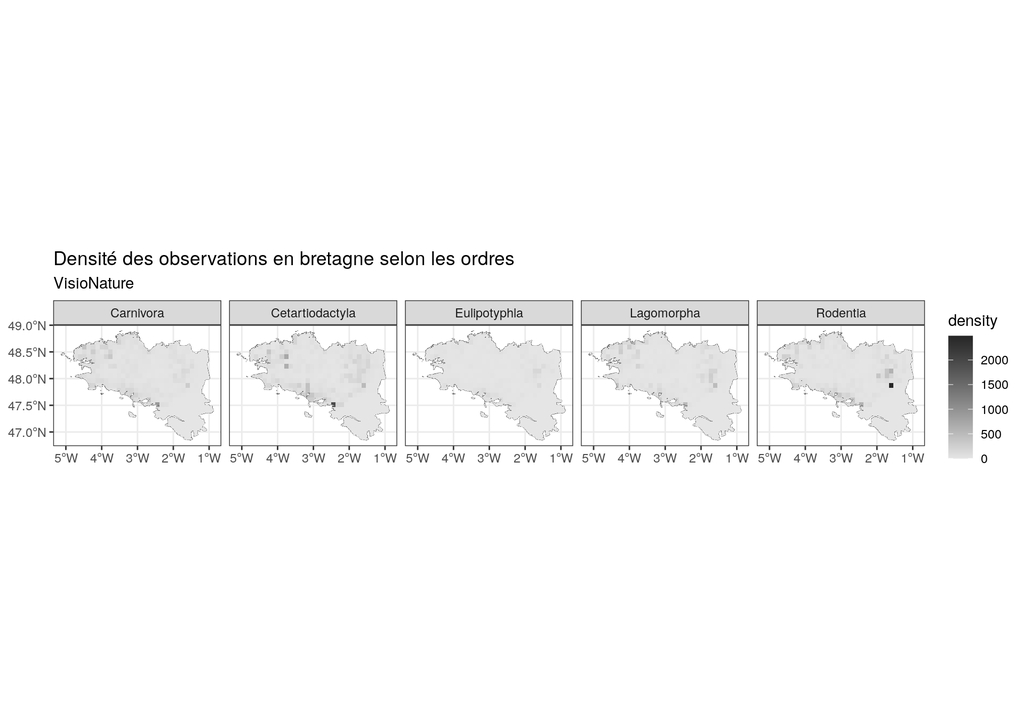

```r
carte_bretagne <- st_set_crs(carte_bretagne, 2154)
carte_bretagne <- st_transform(carte_bretagne, 4326)

# Données geographique

GN_sf <- Total_sf%>%
  dplyr::filter(bdd_rgn == GN)%>%
  dplyr::select(ordre, date)

VN_sf <- Total_sf%>%
  dplyr::filter(bdd_rgn == VN)%>%
  dplyr::select(ordre, date)

ordres <- unique(VN_sf$ordre)

grid <- st_make_grid(carte_bretagne,
                     cellsize = c(0.12, 0.09)) %>%
  st_sf() %>%
  st_set_crs(4326)

# VisioNature
grid_list <- map(ordres, function(o) {
  vis_ord <- VN_sf %>% filter(ordre == o)
  grid_tmp <- grid
  grid_tmp$density <- lengths(st_intersects(grid_tmp, vis_ord))
  grid_tmp$ordre <- o
  grid_tmp
})
grid_sf <- bind_rows(grid_list)
grid_sf <- st_intersection(grid_sf, carte_bretagne)
ggplot() +
  geom_sf(data = carte_bretagne) +
  labs(title = "Densité des observations en bretagne selon les ordres",
       subtitle = VN) +
  geom_sf(data = grid_sf, aes(fill = density), color = NA) +
  scale_fill_gradient(low="gray90", high="gray15") +
  theme_bw() +
  facet_grid(. ~ ordre)
```

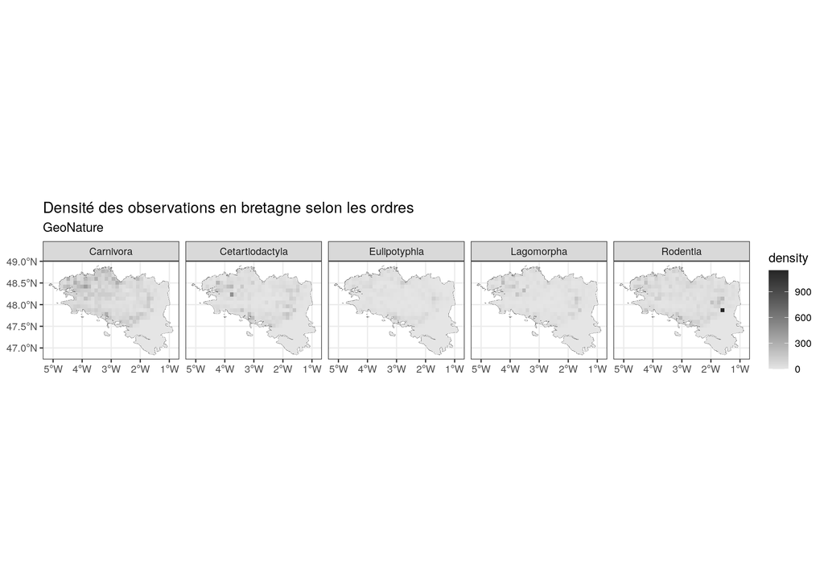

```r
# GeoNature
grid_list <- map(ordres, function(o) {
  vis_ord <- GN_sf %>% filter(ordre == o)
  grid_tmp <- grid
  grid_tmp$density <- lengths(st_intersects(grid_tmp, vis_ord))
  grid_tmp$ordre <- o
  grid_tmp
})
grid_sf <- bind_rows(grid_list)
grid_sf <- st_intersection(grid_sf, carte_bretagne)
ggplot() +
  geom_sf(data = carte_bretagne) +
  labs(title = "Densité des observations en bretagne selon les ordres",
       subtitle = "GeoNature") +
  geom_sf(data = grid_sf, aes(fill = density), color = NA) +
  scale_fill_gradient(low="gray90", high="gray15") +
  theme_bw() +
  facet_grid(. ~ ordre)
```

On ne voit pas grand chose sur la carte de VisioNature à part les 2 principaux observateurs.. Concernant la base de données GeoNature, on dirait que les espèces ont un peu près la même répartition en Bretagne (nord Finistere et Côte d’Armor et sud Ille-et-Vilaine et Morbihan)

Pour info, la graine aléatoire est figée a 12345.

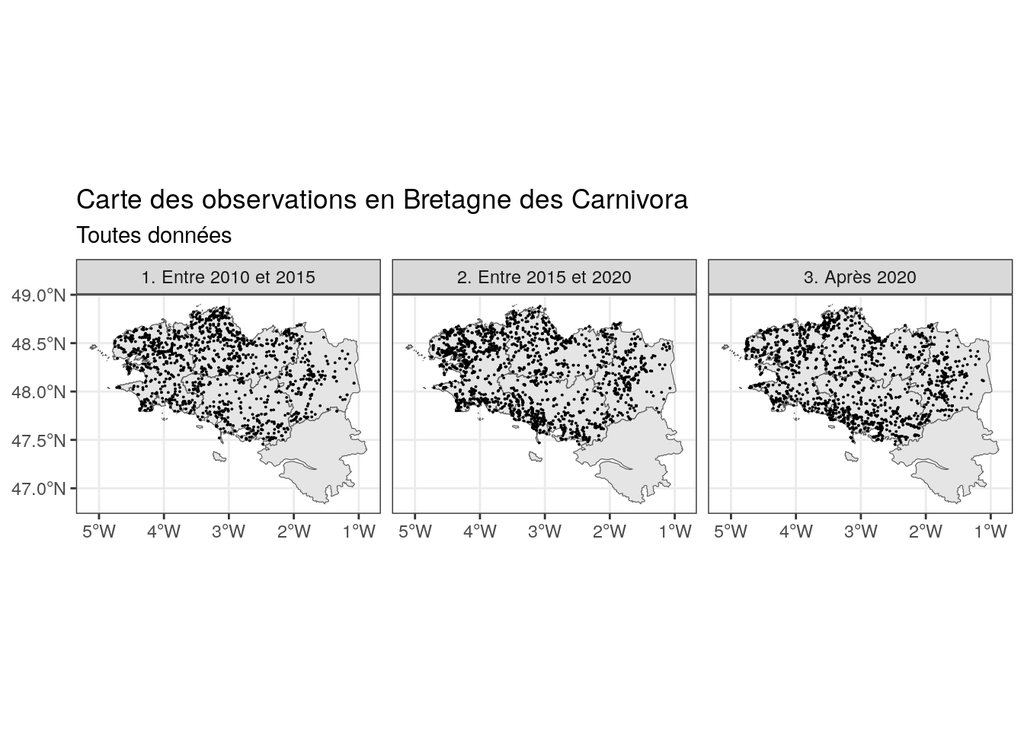

```r
graph_ordre_tranche_annee <- function(ordre_voulu){
  # Creation de la BDD
  ordre_data <- Total_sf %>% filter(ordre == ordre_voulu)
  bdd_props <- prop.table(table(ordre_data$bdd_rgn))
  n_bdd1 <- round(5000 * bdd_props[1])
  n_bdd2 <- 5000 - n_bdd1
  bdd1 <- ordre_data %>%
    filter(bdd_rgn == "GeoNature") %>%
    sample_n(min(n_bdd1, n()))
  bdd2 <- ordre_data %>%
    filter(bdd_rgn == "VisioNature") %>%
    sample_n(min(n_bdd2, n()))

  ordre_graph <- bind_rows(bdd1, bdd2) %>%
    mutate(
      grp_date = case_when(
        date >= as.Date("2010-01-01") & date <= as.Date("2014-12-31") ~ "1. Entre 2010 et 2015",
        date >= as.Date("2015-01-01") & date <= as.Date("2019-12-31") ~ "2. Entre 2015 et 2020",
        date > as.Date("2019-12-31") ~ "3. Après 2020",
        TRUE ~ NA_character_
      )
    ) %>%
    filter(date > as.Date("2010-01-01")) %>%
    sample_frac(1)

  # Transformation pour des données de la carte
  carte_ordre <- ordre_graph %>%
    select(grp_date, ordre, date) %>%
    filter(ordre == ordre_voulu)

  # Plot
  ggplot() +
    geom_sf(data = carte_bretagne) +
    labs(
      title = paste("Carte des observations en Bretagne des", ordre_voulu),
      subtitle = "Toutes données"
    ) +
    geom_sf(data = carte_ordre, size = 0.01) +
    theme_bw() +
    facet_grid(. ~ grp_date)
}

graph_ordre_tranche_annee("Carnivora")
```

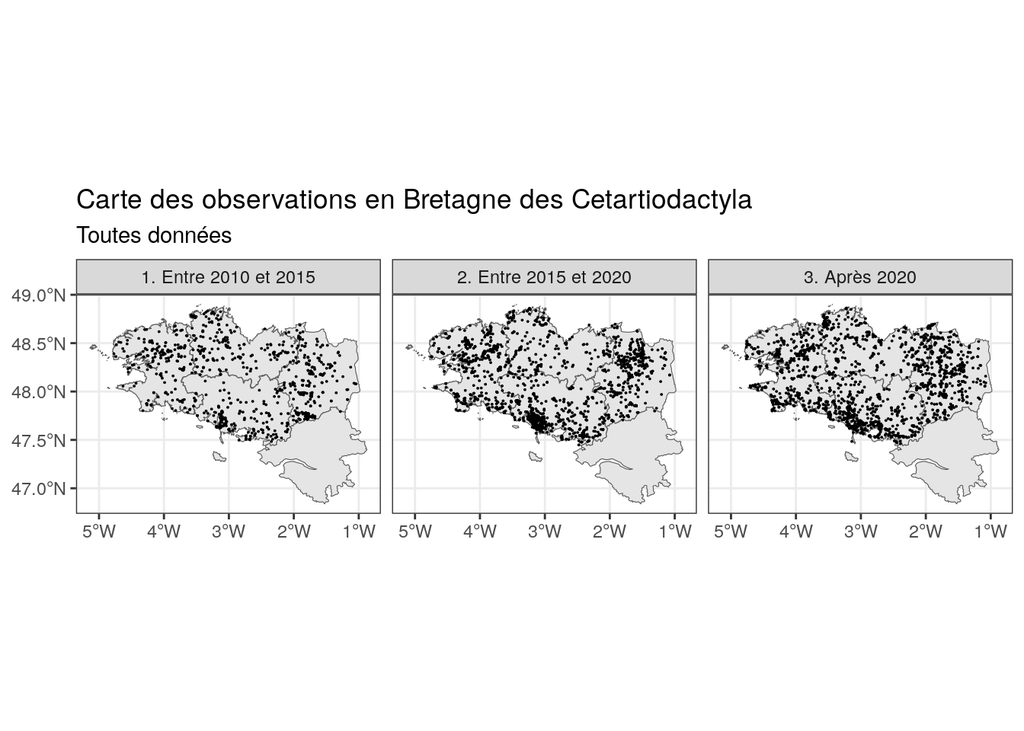

```r
graph_ordre_tranche_annee("Cetartiodactyla")
```

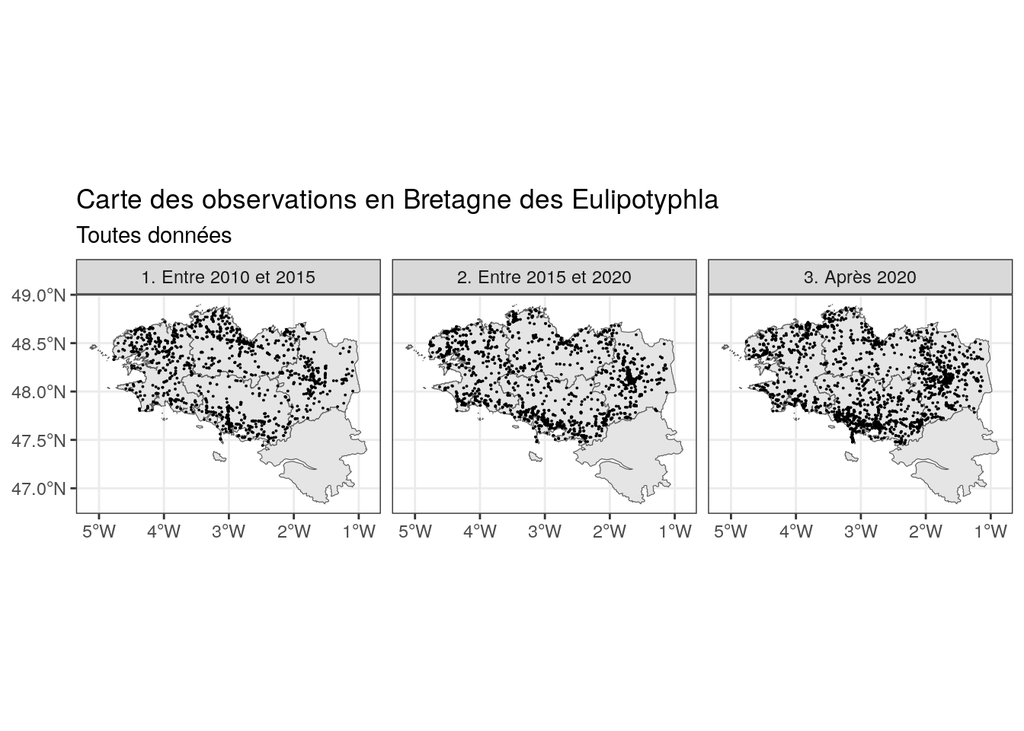

```r
graph_ordre_tranche_annee("Eulipotyphla")
```

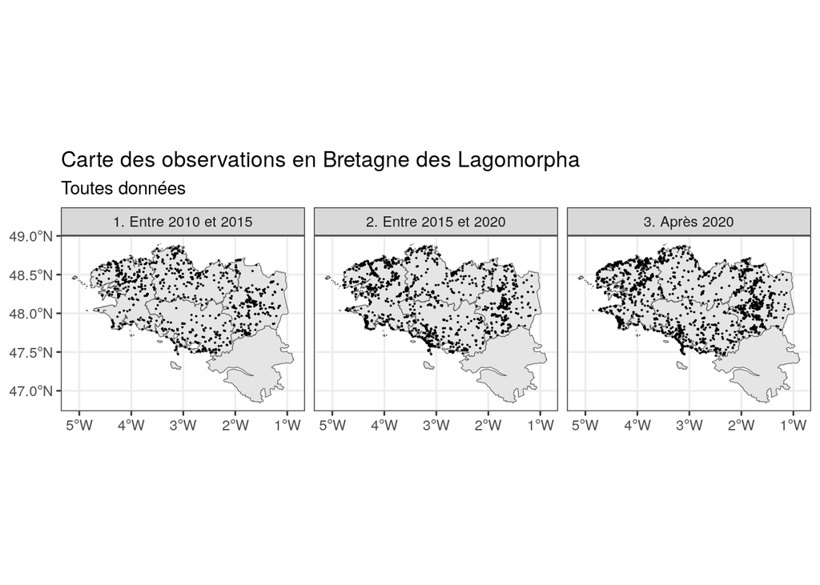

```r
graph_ordre_tranche_annee("Lagomorpha")
```

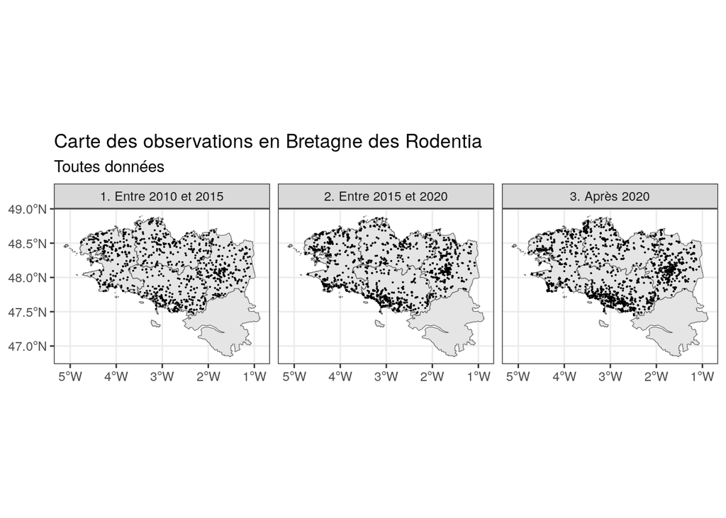

```r
graph_ordre_tranche_annee("Rodentia")
```

On dirait que plus on avance dans les années, plus on retrouve d’individus aux sud de la Bretagne. Ceci peut être car nous avons plus de données de VisioNature au fil du temps qui provient d’ornithologues et les ornithologues sont souvent proches des littoraux.

## 1.4 4. Étude des observateurs

### 1.4.1 Étude des principaux observateurs

Étudier les principaux observateurs peut être important parce qu’ils participent grandement au recueil des données donc un changement de leur comportement implique également un changement du comportement de la base de données.

Ils pourraient introduire des biais:  
- pour un endroit du territoire, s’ils enregistent toujours des observations au même endroit  
- pour une espece, s’ils sont intéressé par une espèce  
- en enregistrant pendant une durée précise dans le temps

```r
Total %>%
  filter(bdd_originale == "GeoNature")%>%
  summarize(nb_observateurs = n_distinct(observateurs))
```

```
## # A tibble: 1 × 1
##   nb_observateurs
##             <int>
## 1            3699
```

```r
Total %>%
  filter(bdd_originale == "VisioNature")%>%
  summarize(nb_observateurs = n_distinct(observateurs))
```

```
## # A tibble: 1 × 1
##   nb_observateurs
##             <int>
## 1            5288
```

On transforme tous les noms en majuscule pour éviter des problèmes.

Nous cherchons les observateurs qui ont le plus contribué aux deux bases de données.

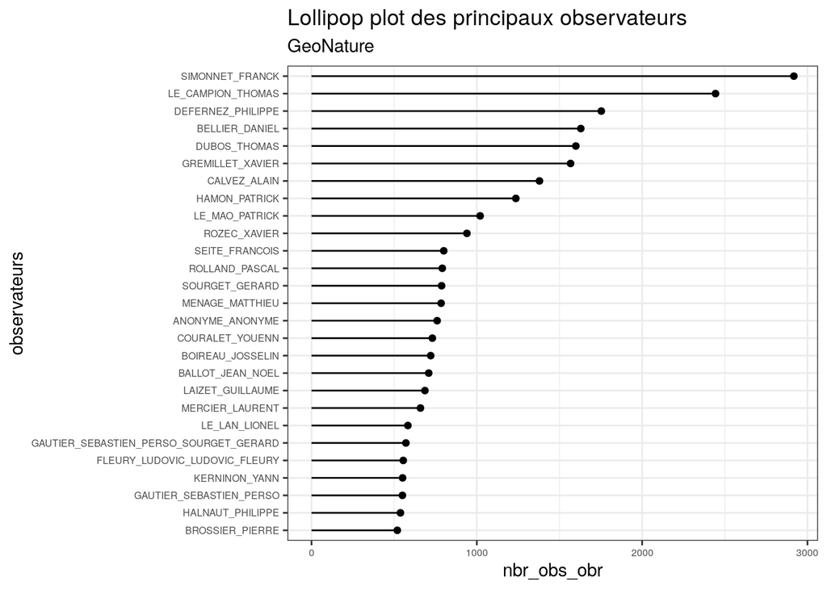

```r
Total_summary_GN <- Total %>%
  filter(bdd_originale == "GeoNature")%>%
  group_by(observateurs) %>%
  summarize(nbr_obs_obr = n()) %>%
  filter(nbr_obs_obr > 500) %>%
  arrange(nbr_obs_obr)

Total_summary_GN$observateurs<- factor(Total_summary_GN$observateurs,
                                       levels = Total_summary_GN$observateurs)

Total_summary_VN <- Total %>%
  filter(bdd_originale == "VisioNature")%>%
  group_by(observateurs) %>%
  summarize(nbr_obs_obr = n()) %>%
  filter(nbr_obs_obr > 500) %>%
  arrange(nbr_obs_obr)

Total_summary_VN$observateurs <- factor(Total_summary_VN$observateurs,
                                      levels = Total_summary_VN$observateurs)

Total_summary_GN%>%
  filter(!is.na(observateurs))%>%
  ggplot(aes(x=observateurs, y=nbr_obs_obr)) +
  geom_point() +
  geom_segment( aes(x=observateurs, xend=observateurs,
                    y=0, yend=nbr_obs_obr))+
  coord_flip()+
  labs(title="Lollipop plot des principaux observateurs",
       subtitle="GeoNature")+
  theme_bw()+
  theme(axis.text=element_text(size=6))
```

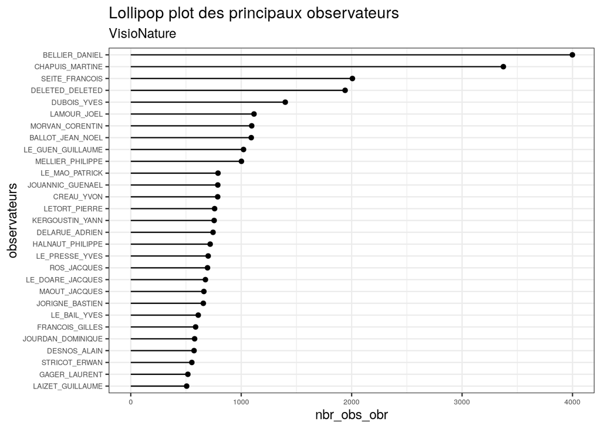

```r
Total_summary_VN%>%
  filter(!is.na(observateurs))%>%
  ggplot(aes(x=observateurs, y=nbr_obs_obr)) +
  geom_point() +
  geom_segment( aes(x=observateurs, xend=observateurs,
                    y=0, yend=nbr_obs_obr))+
  coord_flip()+
  labs(title="Lollipop plot des principaux observateurs",
       subtitle="VisioNature")+
  theme_bw()+
  theme(axis.text=element_text(size=6))
```

Nous remarquons que nous avons des observateurs avec un très grand nombre d’observations comme attendu. Nous ne savons pas si deleted deleted est un observateur. Nous pouvons imaginer que c’est les observations de tous les membres qui ont supprimés leurs comptes.

Pour étudier facilement leur données, nous créons une fonction qui donne rapidement quelques graphiques.

[figure not shown]

```r
stats_observateur <- function(nom_obs, carte){

  # Date
  p1 <- Total_sf %>%
    filter(obsrvtr == toupper(nom_obs),
           date > params$date_min) %>%
    ggplot(aes(date))+
    labs(title="Répartition des dates",
         subtitle = paste("Données de ", toupper(nom_obs))) +
    theme_bw()+
    geom_line(stat="density")+
    scale_x_date(
    breaks = seq(from = min(Total_sf$date),
                 to = max(Total_sf$date),
                 by = "2 years"),
    labels = scales::label_date("%Y")
    )

  # Ordres
  p2 <- Total_sf %>%
    filter(obsrvtr == toupper(nom_obs),
           date > params$date_min) %>%
    ggplot(aes(x = ordre)) +
    geom_bar() +
    labs(title = "Répartition des differents ordres",
         subtitle = paste("Données de ", toupper(nom_obs))) +
    theme_bw()+
    theme(axis.text.x = element_text(angle = 30, hjust = 0.5, vjust = 0.5))

  # Carte
  geo_obsteur <- Total_sf %>%
      filter(date > params$date_min) %>%
      filter(obsrvtr == toupper(nom_obs)) %>%
      dplyr::select(ordre,
                    date)
  p3 <- ggplot() +
      geom_sf(data = carte) +
      labs(title = "Carte des observations",
           subtitle = paste("Données de ", toupper(nom_obs))) +
      geom_sf(data = geo_obsteur, size=0.01) +
      theme_bw()


  # Affichage des plots
  p1 + p2 + p3
  }

setwd("~/work/AnalyseDonneesOpportunisteGMB/donnees/DepartementsOuest")
carte_bretagne <- st_read("LIM_ADM_DepartementsOuest.shp")
carte_bretagne <- st_set_crs(carte_bretagne, 2154)
carte_bretagne <- st_transform(carte_bretagne, 4326)

stats_observateur(nom_obs="BELLIER DANIEL",
                  carte=carte_bretagne)
```

[figure not shown]

```r
stats_observateur(nom_obs="CHAPUIS MARTINE",
                  carte=carte_bretagne)
```

[figure not shown]

```r
stats_observateur(nom_obs="SéITé FRANçOIS",
                  carte=carte_bretagne)
```

[figure not shown]

```r
stats_observateur(nom_obs="deleted deleted",
                  carte=carte_bretagne)
```

[figure not shown]

```r
stats_observateur(nom_obs="simonnet franck",
                  carte=carte_bretagne)
```

[figure not shown]

```r
stats_observateur(nom_obs="le campion thomas",
                  carte=carte_bretagne)
```

Nous remarquons que:  
- BELLIER DANIEL observe beaucoup de rongeurs autour de Rennes.  
- CHAPUIS MARTINE observe uniquement a un endroit précis.  
- DELETED DELETED, semble être surtout dans le finistère ce qui est étonnant si ce sont plusieurs personnes.

### 1.4.2 Habitudes des observateurs?

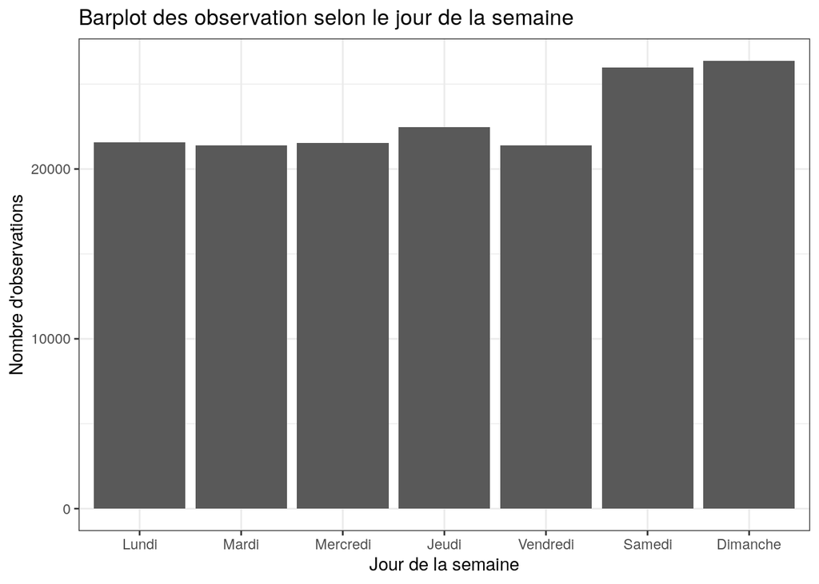

```r
Total%>%
  ggplot(aes(as.factor(wday(date,
                            week_start = getOption("lubridate.week.start", 1)))))+
  labs(title="Barplot des observation selon le jour de la semaine",
       y="Nombre d'observations",
       x="Jour de la semaine")+
  theme_bw()+
  geom_bar()+
  scale_x_discrete(labels=c("1" = "Lundi",
                            "2" = "Mardi",
                            "3" = "Mercredi",
                            "4" = "Jeudi",
                            "5" = "Vendredi",
                            "6" = "Samedi",
                            "7" = "Dimanche"))
```

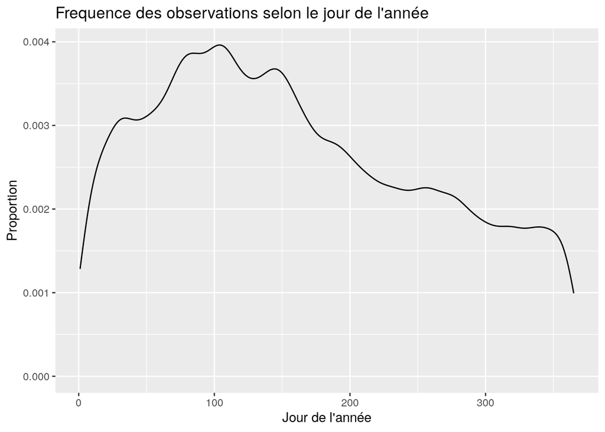

```r
Total %>%
  filter(date > params$date_min)%>%
  mutate(jour_annee = qday(date)+(quarter(date,with_year = FALSE)-1)*91)%>%
  ggplot(aes(jour_annee)) +
  labs(title="Frequence des observations selon le jour de l'année",
       y="Proportion",
       x="Jour de l'année")+
  geom_density()
```

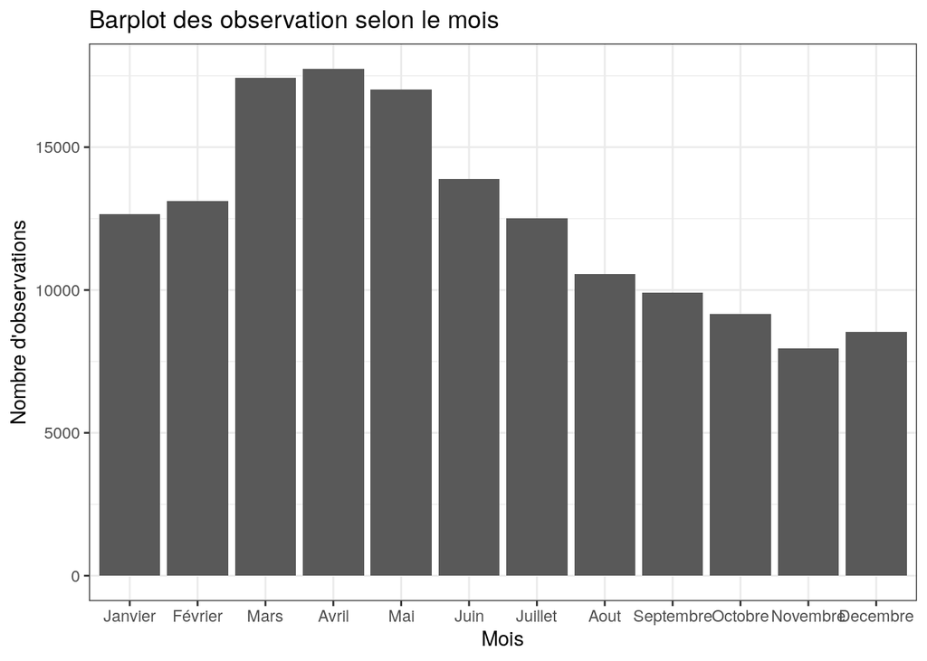

```r
Total%>%
    filter(date > params$date_min)%>%
    ggplot(aes(factor(month(date))))+
    labs(title="Barplot des observation selon le mois",
         y="Nombre d'observations",
         x="Mois")+
    theme_bw()+
    geom_bar()+
    scale_x_discrete(labels=c("1" = "Janvier",
                              "2" = "Février",
                              "3" = "Mars",
                              "4" = "Avril",
                              "5" = "Mai",
                              "6" = "Juin",
                              "7" = "Juillet",
                              "8" = "Aout",
                              "9" = "Septembre",
                              "10" = "Octobre",
                              "11" = "Novembre",
                              "12" = "Decembre"))
```

### 1.4.3 Differences parmi les observateurs

```r
nb_observations <- Total %>%
  group_by(observateurs) %>%
  summarise(total_obs = n(), .groups = "drop")

max_technique <- Total%>%
  group_by(observateurs) %>%
  summarise(tech_obs_max = collapse::fmode(technique_observation))

max_etat_bio <- Total%>%
  group_by(observateurs) %>%
  summarise(etat_bio_max = collapse::fmode(etat_biologique))

Observateurs <- nb_observations %>%
  left_join(nb_ordre(nom_ordre = "Carnivora"), by = "observateurs") %>%
  left_join(nb_ordre(nom_ordre = "Cetartiodactyla"), by = "observateurs") %>%
  left_join(nb_ordre(nom_ordre = "Eulipotyphla"), by = "observateurs") %>%
  left_join(nb_ordre(nom_ordre = "Lagomorpha"), by = "observateurs") %>%
  left_join(nb_ordre(nom_ordre = "Rodentia"), by = "observateurs")%>%
  left_join(max_technique, by = "observateurs")%>%
  left_join(max_etat_bio, by = "observateurs")

Observateurs <- Observateurs %>%
  mutate(nb_carnivora = ifelse(is.na(nb_carnivora), 0, nb_carnivora),
         nb_cetartiodactyla = ifelse(is.na(nb_cetartiodactyla), 0, nb_cetartiodactyla),
         nb_eulipotyphla = ifelse(is.na(nb_eulipotyphla), 0, nb_eulipotyphla),
         nb_lagomorpha = ifelse(is.na(nb_lagomorpha), 0, nb_lagomorpha),
         nb_rodentia = ifelse(is.na(nb_rodentia), 0, nb_rodentia)
  )

Observateurs$shannon <- vegan::diversity(Observateurs[,3:7])

Observateurs$Pielou <- Observateurs$shannon / log(vegan::specnumber(Observateurs[,3:7]))
Observateurs <- Observateurs %>%
  mutate(Pielou = ifelse(shannon==0, 0, Pielou))

Observateurs <- Observateurs%>%
  mutate(prop_carnivora = nb_carnivora / total_obs,
         prop_cetartiodactyla = nb_cetartiodactyla / total_obs,
         prop_eulipotyphla = nb_eulipotyphla / total_obs,
         prop_lagomorpha = nb_lagomorpha / total_obs,
         prop_rodentia = nb_rodentia / total_obs,
         tech_obs_max = paste("Tech d'obs: ", tech_obs_max, sep=""),
         etat_bio_max = paste("Etat bio: ", etat_bio_max, sep="")
         )


rm(max_etat_bio, max_technique)
```

On se demande a quoi ressemble la répartition des Indice de Pielou

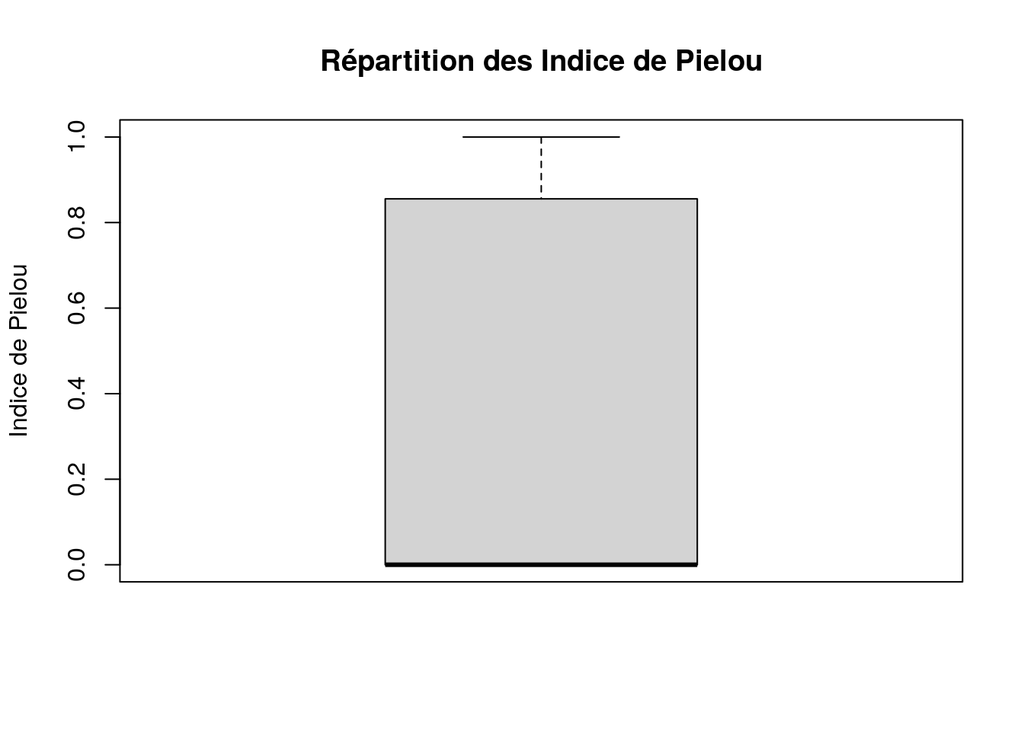

```r
boxplot(Observateurs$Pielou,
        main="Répartition des Indice de Pielou",
        ylab="Indice de Pielou")
```

```r
summary(Observateurs$Pielou)
```

```
##    Min. 1st Qu.  Median    Mean 3rd Qu.    Max.
##  0.0000  0.0000  0.0000  0.3081  0.8550  1.0000
```

On remarque qu’il y a enormément d’observateurs qui on un Indice nul, ou presque. Ceci est normal car beaucoup ont observé uniquement une observation. (Par exemple, tous les NA ont été considéré comme des observateurs uniques, et d’autres ont observé a plusieurs.) On a 4032 observateurs qui ont uniquement une observation tandis qu’il y a 7869 observateurs dans la base de donnée.

Le 4e quartile est aussi assez sérré. Il y a donc beaucoup d’individus avec une assez bonne diversité dans leurs observations. (1/4 d’entre eux sont entre 0.86 et 1 d’Indice.)

On fait une ACP sur cette base de donnée, et on obtiens ceci:

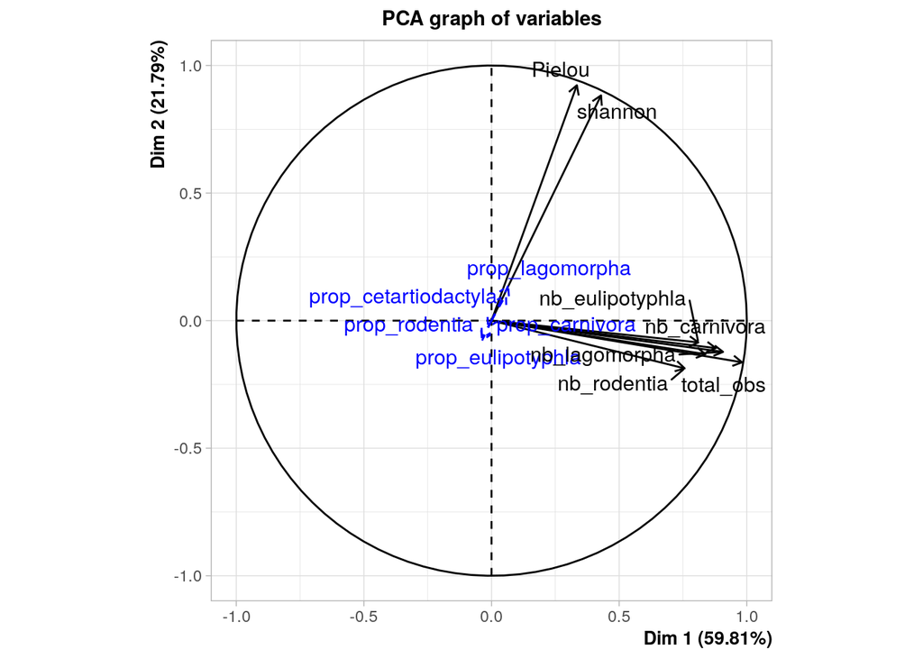

```r
res.PCA<-PCA(Observateurs[,-c(1)],quali.sup=c(7,8),
             quanti.sup=c(11,12,13,14,15),graph=FALSE)
plot.PCA(res.PCA,choix='var')
```

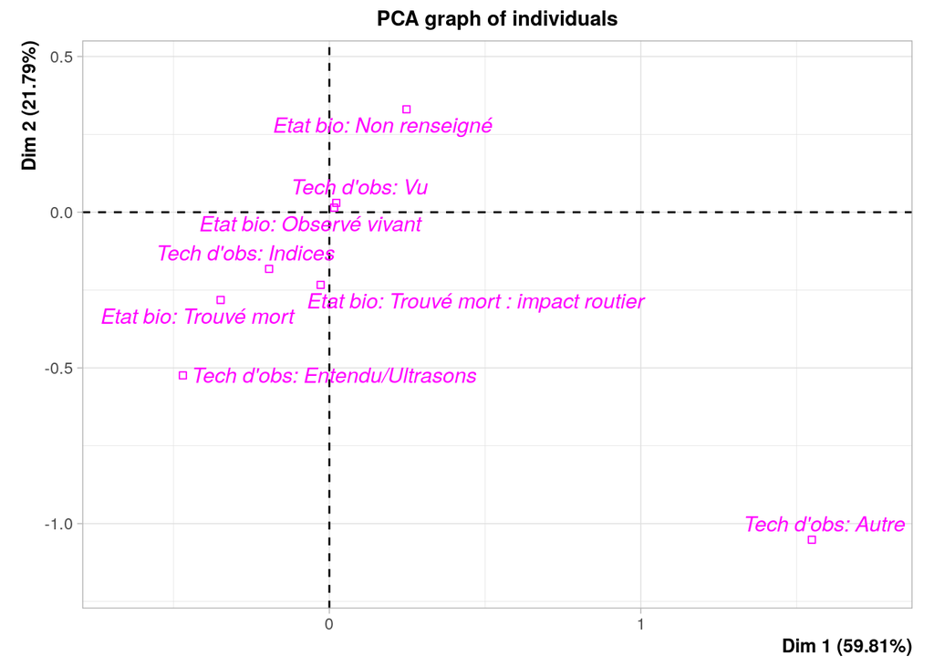

```r
plot.PCA(res.PCA,invisible=c('ind','ind.sup'), label =c('quali'))
```

```r
summary(res.PCA)
```

```
##
## Call:
## PCA(X = Observateurs[, -c(1)], quanti.sup = c(11, 12, 13, 14,
##      15), quali.sup = c(7, 8), graph = FALSE)
##
##
## Eigenvalues
##                        Dim.1   Dim.2   Dim.3   Dim.4   Dim.5   Dim.6   Dim.7
## Variance               4.785   1.743   0.577   0.502   0.173   0.150   0.071
## % of var.             59.807  21.792   7.208   6.273   2.161   1.877   0.883
## Cumulative % of var.  59.807  81.599  88.807  95.080  97.241  99.117 100.000
##                        Dim.8
## Variance               0.000
## % of var.              0.000
## Cumulative % of var. 100.000
##
## Individuals (the 10 first)
##                                            Dist    Dim.1    ctr   cos2    Dim.2
## 1                                      |  1.043 | -0.564  0.001  0.292 | -0.876
## 2                                      |  1.042 | -0.563  0.001  0.292 | -0.876
## 3                                      |  1.783 |  0.082  0.000  0.002 |  1.659
## 4                                      |  2.614 |  0.372  0.000  0.020 |  2.556
## 5                                      |  3.026 |  1.978  0.011  0.427 |  2.019
## 6                                      |  2.166 |  0.539  0.001  0.062 |  2.070
## 7                                      |  1.544 |  0.119  0.000  0.006 |  1.531
## 8                                      |  1.565 |  0.046  0.000  0.001 |  1.448
## 9                                      |  2.154 |  0.500  0.001  0.054 |  2.008
## 10                                     |  0.864 |  0.220  0.000  0.065 |  0.655
##                                           ctr   cos2    Dim.3    ctr   cos2
## 1                                       0.006  0.706 | -0.005  0.000  0.000 |
## 2                                       0.006  0.706 | -0.025  0.000  0.001 |
## 3                                       0.020  0.866 |  0.143  0.000  0.006 |
## 4                                       0.048  0.957 |  0.186  0.001  0.005 |
## 5                                       0.030  0.445 |  0.173  0.001  0.003 |
## 6                                       0.032  0.914 | -0.168  0.001  0.006 |
## 7                                       0.017  0.984 |  0.097  0.000  0.004 |
## 8                                       0.015  0.856 |  0.119  0.000  0.006 |
## 9                                       0.030  0.869 |  0.257  0.001  0.014 |
## 10                                      0.003  0.575 |  0.390  0.003  0.204 |
##
```

[output cut: 38 more lines]

```
## Tech d'obs: Indices                    |  0.282 | -0.193  0.469 -2.855 | -0.182
## Tech d'obs: Vu                         |  0.040 |  0.022  0.311  2.374 |  0.030
## Etat bio: Non renseigné                |  0.459 |  0.248  0.291  2.261 |  0.330
## Etat bio: Observé vivant               |  0.030 |  0.015  0.261  1.445 |  0.015
## Etat bio: Trouvé mort                  |  0.452 | -0.349  0.596 -3.825 | -0.282
## Etat bio: Trouvé mort : impact routier |  0.334 | -0.028  0.007 -0.227 | -0.233
##                                          cos2 v.test    Dim.3   cos2 v.test
## Tech d'obs: Autre                       0.214 -3.908 |  0.545  0.057  3.520 |
## Tech d'obs: Entendu/Ultrasons           0.552 -1.864 |  0.011  0.000  0.070 |
## Tech d'obs: Indices                     0.416 -4.452 | -0.006  0.000 -0.241 |
## Tech d'obs: Vu                          0.569  5.316 | -0.001  0.001 -0.367 |
## Etat bio: Non renseigné                 0.518  4.995 | -0.053  0.013 -1.399 |
## Etat bio: Observé vivant                0.237  2.278 |  0.016  0.292  4.397 |
## Etat bio: Trouvé mort                   0.388 -5.114 | -0.039  0.008 -1.239 |
## Etat bio: Trouvé mort : impact routier  0.488 -3.144 | -0.217  0.420 -5.073 |
```

Le premier axe semble représenter un grand nombre d’observations, et le deuxieme axe la diversité.

Les Individus ayant principalement des “technique biologique: autre” sont ceux qui ont beaucoup d’observation. Ceux ayant surtout remarqué des animaux morts, ont peu d’observations. De même pour une technique d’ob Inconnu et Entendu/Ultrasons.

Les individus qui ont principalement observé des animaux mort due a un impact routier ont peu de diversité dans les espèces qu’ils remarquent. Pareil pour Entendu/Ultrasons, Inconnu et Indices, et Trouvé Mort. Les animaux avec une tech d’obs Non Renseigné (ou Vu mais moins) le sont par des gens avec une grande diversité d’observations.

Clustering : On voit pas grand chose

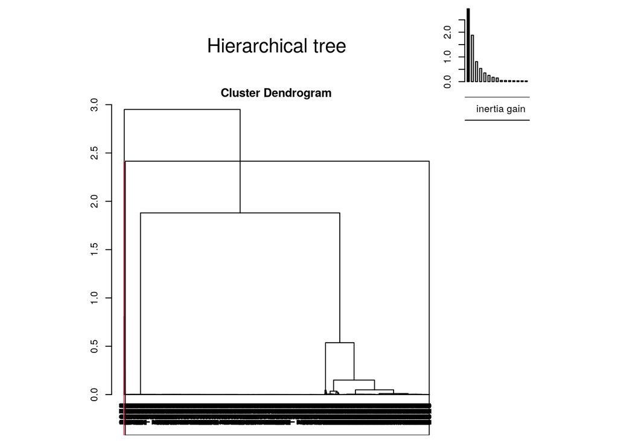

```r
res.HCPC<-HCPC(res.PCA,nb.clust=2,consol=FALSE,graph=FALSE)
plot.HCPC(res.HCPC,choice='tree',title='Hierarchical tree')
```

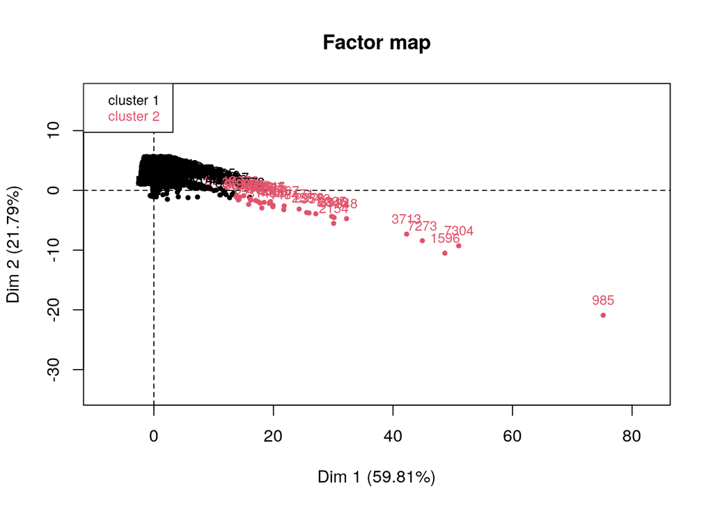

```r
plot.HCPC(res.HCPC,choice='map',draw.tree=FALSE,title='Factor map')
```

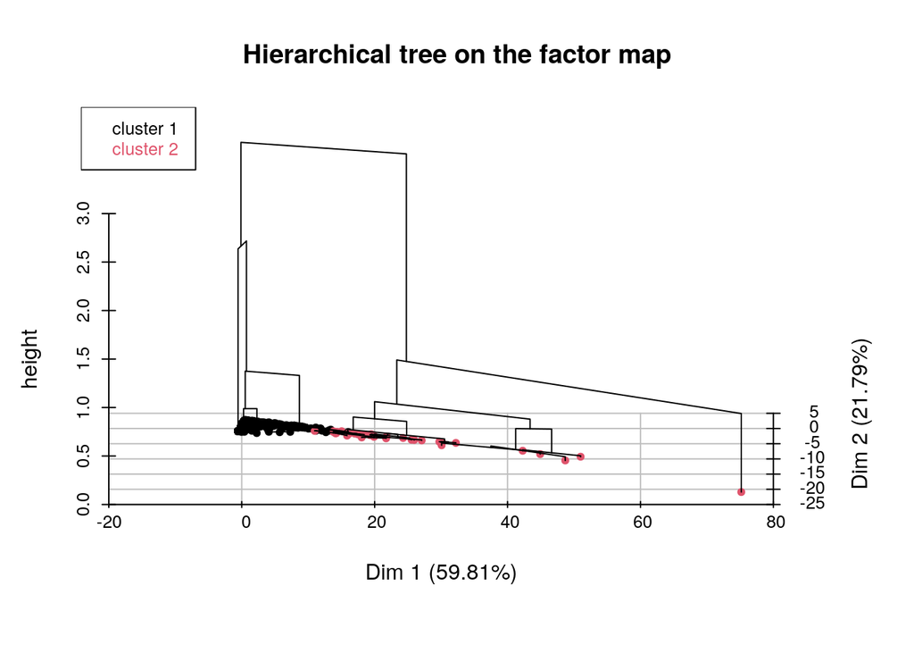

```r
plot.HCPC(res.HCPC,choice='3D.map',ind.names=FALSE,centers.plot=FALSE,angle=90,title='Hierarchical tree on the factor map')
```

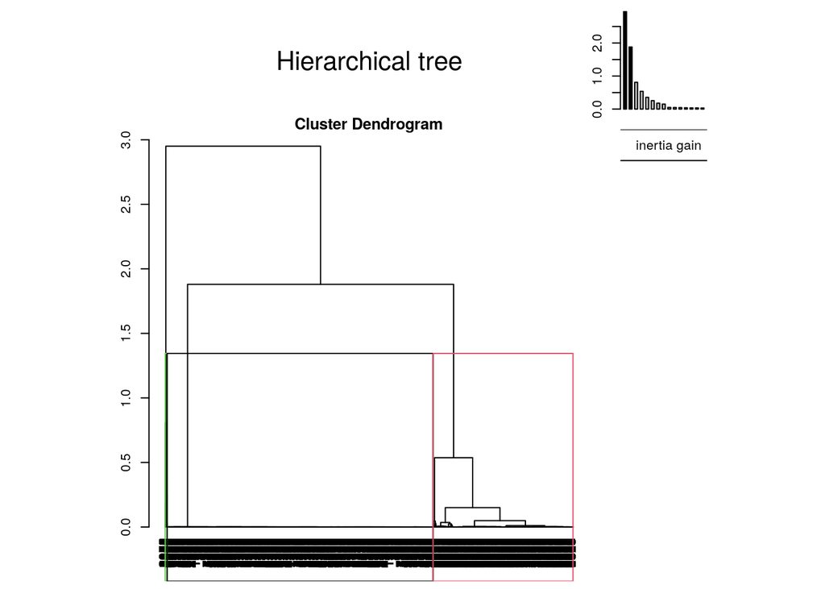

```r
res.HCPC<-HCPC(res.PCA,nb.clust=3,consol=FALSE,graph=FALSE)
plot.HCPC(res.HCPC,choice='tree',title='Hierarchical tree')
```

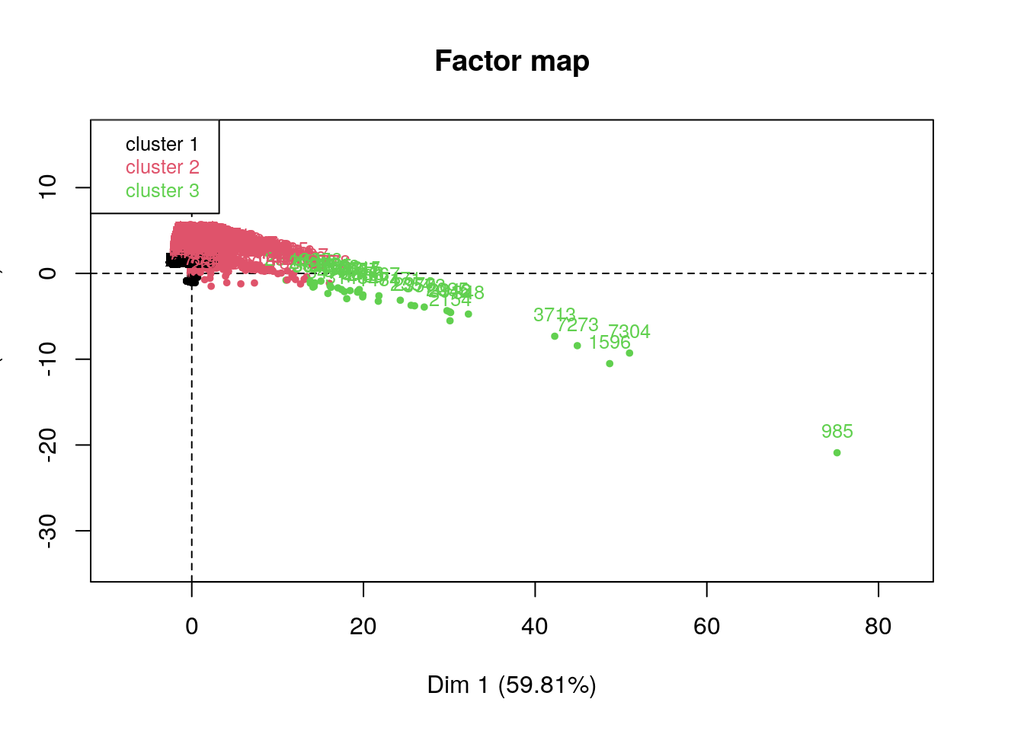

```r
plot.HCPC(res.HCPC,choice='map',draw.tree=FALSE,title='Factor map')
```

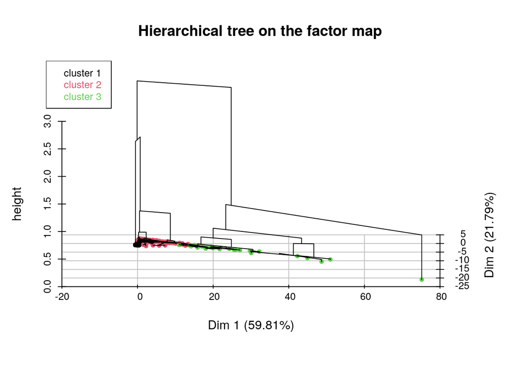

```r
plot.HCPC(res.HCPC,choice='3D.map',ind.names=FALSE,centers.plot=FALSE,angle=90,title='Hierarchical tree on the factor map')
```